# Project Business Statistics: E-news Express

## Define Problem Statement and Objectives

### Problem Statement

1. Decline in monthly subscription of E-news Express as compared to the past.
2. Current web is not well designed in terms of its outline and contents.

### Objectives

Increase E-news Express subscribers thus testing the effectiveness of a newly created landing page by,

1. Finding out whether users spend more time on the newly created landing page as compared to the old landing page.
2. Establishing whether conversion depends on languge preference.
3. Determining whether time spent on the new page is different for different users.

## Data Dictionary

The data contains information regarding the interaction of users in both groups with the two versions of the landing page.

1. user_id - Unique user ID of the person visiting the website
2. group - Whether the user belongs to the first group (control) or the second group (treatment)
3. landing_page - Whether the landing page is new or old
4. time_spent_on_the_page - Time (in minutes) spent by the user on the landing page
5. converted - Whether the user gets converted to a subscriber of the news portal or not
6. language_preferred - Language chosen by the user to view the landing page

## Import all the necessary libraries

```python
# Installing the libraries with the specified version.
!pip install numpy==1.25.2 pandas==1.5.3 matplotlib==3.7.1 seaborn==0.13.1 scipy==1.11.4 -q --user
```

```python
import numpy as np
import pandas as pd
from matplotlib import pyplot as plt
import seaborn as sns
```

## Reading the Data into a DataFrame

```python
# importing data from google drive
from google.colab import drive
drive.mount('/content/drive')
```

```python
data = pd.read_csv('/content/drive/My Drive/abtest.csv')
```

## Explore the dataset and extract insights using Exploratory Data Analysis

```python
# first 5 rows of the dataset
data.head()
```

|  | user_id | group | landing_page | time_spent_on_the_page | converted | language_preferred |
| --- | --- | --- | --- | --- | --- | --- |
| 0 | 546592 | control | old | 3.48 | no | Spanish |
| 1 | 546468 | treatment | new | 7.13 | yes | English |
| 2 | 546462 | treatment | new | 4.40 | no | Spanish |
| 3 | 546567 | control | old | 3.02 | no | French |
| 4 | 546459 | treatment | new | 4.75 | yes | Spanish |

```python
# last 5 rows of the dataset
data.tail()
```

|  | user_id | group | landing_page | time_spent_on_the_page | converted | language_preferred |
| --- | --- | --- | --- | --- | --- | --- |
| 95 | 546446 | treatment | new | 5.15 | no | Spanish |
| 96 | 546544 | control | old | 6.52 | yes | English |
| 97 | 546472 | treatment | new | 7.07 | yes | Spanish |
| 98 | 546481 | treatment | new | 6.20 | yes | Spanish |
| 99 | 546483 | treatment | new | 5.86 | yes | English |

```python
# shape of data
data.shape
```

```
(100, 6)
```

**Observation:**

- **The data set contains 100 rows and 6 columns**

```python
# data types of the columns
data.info()
```

```
<class 'pandas.core.frame.DataFrame'>
RangeIndex: 100 entries, 0 to 99
Data columns (total 6 columns):
 #   Column                  Non-Null Count  Dtype
---  ------                  --------------  -----
 0   user_id                 100 non-null    int64
 1   group                   100 non-null    object
 2   landing_page            100 non-null    object
 3   time_spent_on_the_page  100 non-null    float64
 4   converted               100 non-null    object
 5   language_preferred      100 non-null    object
dtypes: float64(1), int64(1), object(4)
memory usage: 4.8+ KB
```

**Observation:**

- **There are 4 categorical columns ans 2 numeric columns**

```python
 # missing values checking
data.isnull().sum()
```

|  | 0 |
| --- | --- |
| user_id | 0 |
| group | 0 |
| landing_page | 0 |
| time_spent_on_the_page | 0 |
| converted | 0 |
| language_preferred | 0 |

**dtype:** int64

**Observation:**

- **There are no missing values**

```python
 # statistical summary
data.describe()
```

|  | user_id | time_spent_on_the_page |
| --- | --- | --- |
| count | 100.000000 | 100.000000 |
| mean | 546517.000000 | 5.377800 |
| std | 52.295779 | 2.378166 |
| min | 546443.000000 | 0.190000 |
| 25% | 546467.750000 | 3.880000 |
| 50% | 546492.500000 | 5.415000 |
| 75% | 546567.250000 | 7.022500 |
| max | 546592.000000 | 10.710000 |

**Observation:**

- **Mean time spent on the page is 5.38 minutes and median time spent on the page is 5.41 minutes**

```python
# duplicate checks
data.duplicated().sum()
```

```
0
```

**Observation:**

- **There are no duplicates**

```python
 # sample mean of the time spent on the page
data['time_spent_on_the_page'].mean()
```

```
5.377800000000001
```

**Observation:**

- **Sample mean is 5.38 minutes**

### **Time spent on the page**

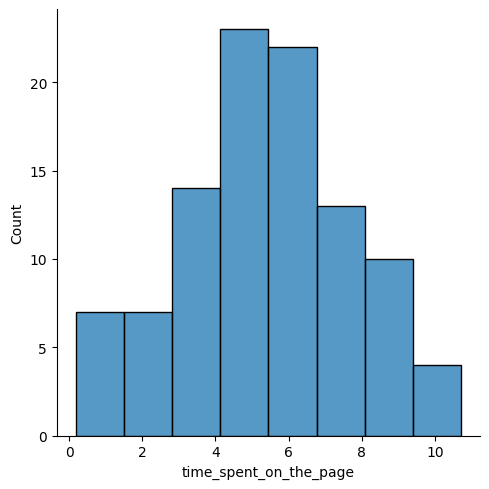

```python
 # distribution plot of time spent on the page
sns.displot(data['time_spent_on_the_page'])
plt.show()
```

**Observation:**

- **The distribution of time spent on the page is normal**

### **Group**

```python
# number of customers for the each group
data['group'].value_counts()
```

| group | count |
| --- | --- |
| control | 50 |
| treatment | 50 |

**dtype:** int64

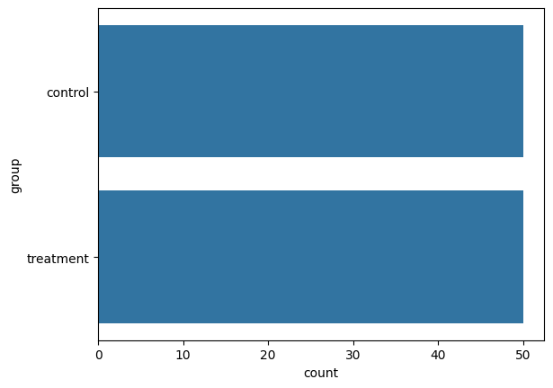

```python
# distribution for groups
sns.countplot(data['group'])
plt.show()
```

**Observation:**

- **Both groups contain 50 users**

### **Landing page**

```python
 # value count for landing page
data['landing_page'].value_counts()
```

| landing_page | count |
| --- | --- |
| old | 50 |
| new | 50 |

**dtype:** int64

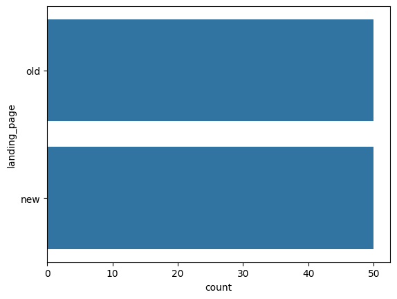

```python
 # distribution for landing page
sns.countplot(data['landing_page'])
plt.show()
```

**Observation:**

- **Landing page has 50 users for new and 50 users for old**

### **Language Preference**

```python
 # value count for language preference
data['language_preferred'].value_counts()
```

| language_preferred | count |
| --- | --- |
| Spanish | 34 |
| French | 34 |
| English | 32 |

**dtype:** int64

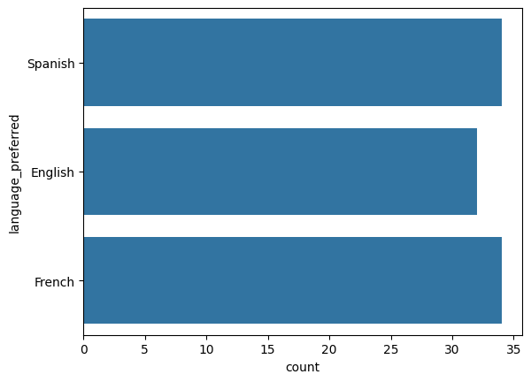

```python
 # distribution for language preference
sns.countplot(data['language_preferred'])
plt.show()
```

**Observation:**

- **Both Spanish and French had 34 users**
- **32 users preferred English**

### **Converted**

```python
# value count for coverted users
data['converted'].value_counts()
```

| converted | count |
| --- | --- |
| yes | 54 |
| no | 46 |

**dtype:** int64

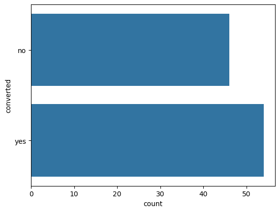

```python
# distribution for coverted users
sns.countplot(data['converted'])
plt.show()
```

**Observation:**

- **54 users were converted while 46 were not**

## **Relationship between Landing page and Time spent on the page**

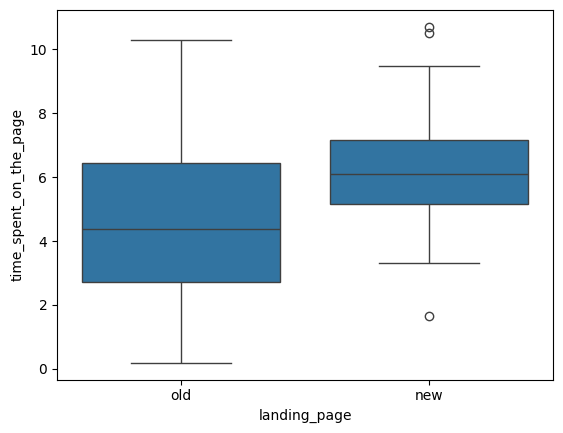

```python
# for relationship between landing page and time spent on the page
sns.boxplot(x='landing_page', y='time_spent_on_the_page', data=data)
plt.show()
```

## **Relationship between conversion status and time spent on the page**

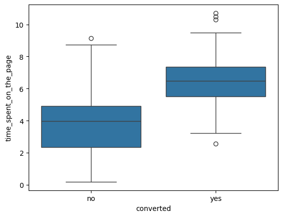

```python
 # relationship between conversion status and time spent on the page
sns.boxplot(x='converted', y='time_spent_on_the_page', data=data)
plt.show()
```

## **Relationship between language preferred vs Time spent on the page**

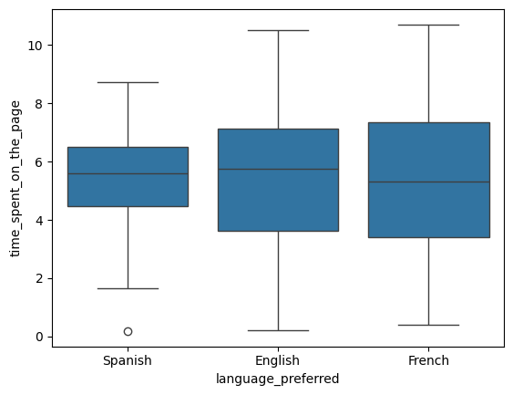

```python
# Relationship between language preferred vs Time spent on the page
sns.boxplot(x='language_preferred', y='time_spent_on_the_page', data=data)
plt.show()
```

**Observations:**

- **There is an outlier for users who preferred Spanish.**
- **Most users who spent less than 2 mins or spent more than 9 mins on the page preferred either English or French.**
- **Users who preferred Spanish mostly spent between 1.9 mins to 9 mins on the page.**

### 1. Do the users spend more time on the new landing page than the existing landing page?

### Perform Visual Analysis

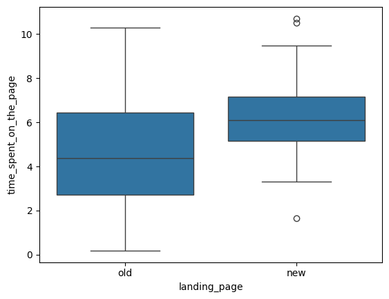

```python
# comparison between time spent on new landing page and old landing page
sns.boxplot(x='landing_page', y='time_spent_on_the_page', data=data)
plt.show()
```

**Observations:**

- **There are some outliers for time spent on the new page**
- **Median time spent on the new and old are different**
- **Minimum time spent on the new page is higher as compared to the old page**

### Step 1: Define the null and alternate hypotheses

Let $\mu_1, \mu_2$ be the mean time spent on the old and new pages respectively.

Null hypothesis

> $H_0:\mu_1=\mu_2$

Against the Alternate hypothesis

> $H_a:\mu_1<\mu_2$

### Step 2: Select Appropriate test

```python
# computing sample standard deviation from data
data.groupby('landing_page').agg({'time_spent_on_the_page': 'std'})
```

| landing_page | time_spent_on_the_page |
| --- | --- |
| new | 1.817031 |
| old | 2.581975 |

**Observations

- **The standard deviation of time spent on the new page is 1.81.**
- **The standard deviation of time spent on the old page is 2.58.**
- Data is continuous since it is measured on a continuous scale(time).
- Normally distributed populations from the Histogram above.
- Independent populations - control group and treatment group.
- Unknown standard deviations.
- Random sampling from the population - 100 users randomly selected

**Two indepedent sample t-test for means with unequal standard deviations is the appropriate test to use since it satisfies the above**

### Step 3: Decide the significance level

**Significance level is given as 0.05 ($\alpha = 0.05$)**

### Step 4: Collect and prepare data

```python
# computing sample mean from data
data.groupby('landing_page').agg({'time_spent_on_the_page': 'mean'})
```

| landing_page | time_spent_on_the_page |
| --- | --- |
| new | 6.2232 |
| old | 4.5324 |

**Observation:**

- **The mean time spent on the new page is 6.22 mins.**
- **The mean time spent on the old page is 4.53 mins.**

### Step 5: Calculate the p-value

```python
# importing required function
from scipy.stats import ttest_ind
```

```python
# finding p value
t_statistic, p_value = ttest_ind(data[data['landing_page'] == 'new']['time_spent_on_the_page'],
                                 data[data['landing_page'] == 'old']['time_spent_on_the_page'],equal_var=False,alternative='less')

print("P-value:", p_value)
```

```
P-value: 0.9998607618774834
```

**Observation:**

- **P value is 0.99986.**

### Step 6: Compare the p-value with $\alpha$

```python
if p_value < 0.05:
    print("Reject null hypothesis")
else:
    print("Fail to reject null hypothesis")
```

```
Fail to reject null hypothesis
```

**Observation:**

## 2. Is the conversion rate (the proportion of users who visit the landing page and get converted) for the new page greater than the conversion rate for the old page?

### **Comparion between conversion rate for new and old page**

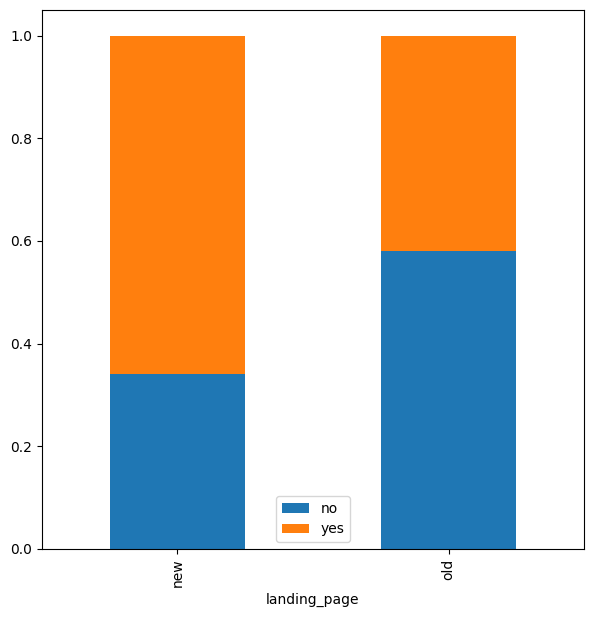

```python
# graphical comparison between conversion rate for new and old page
pd.crosstab(data['landing_page'],data['converted'],normalize='index').plot(kind="bar", figsize=(7,7), stacked=True)
plt.legend()
plt.show()
```

**Observations:**

- **More users converted on the new landing page as compared to the old - yet to verify by testing**

### Null and alternate hypotheses

Let $\mu_1, \mu_2$ be the proportions of conversion on the old and new pages respectively.

Null hypothesis

> $H_0:\mu_1=\mu_2$

Against the Alternate hypothesis

> $H_a:\mu_1<\mu_2$

### Appropriate test selection

- Population is binomally distributed - User either converts or does not.
- Population is randomly sampled as informed.
- Can the binomial distribution approximated to normal distribution - Yes. For binary data, CLT works slower than usual. The standard thing is to check whether np and n(1-p) are greater than or equal to 10. Here, n and p refer to the sample size and sample proportion respectively.

**Observation:**

**Two proportion z - test is the appropriate test selection since it satisfies the above conditions**

**Significance level is given as 0.05 ($\alpha = 0.05$)**

### Collection and preparation of data

```python
# number of converted users for each group
old_converted = data[data['landing_page'] == 'old']['converted'].value_counts()['yes'] # control

new_converted = data[data['landing_page'] == 'new']['converted'].value_counts()['yes'] # treatment

print("Number of converted users for old page:", old_converted)
print("Number of converted users for new page:", new_converted)
```

```
Number of converted users for old page: 21
Number of converted users for new page: 33
```

## P value calculation

```python
# required function importing
from statsmodels.stats.proportion import proportions_ztest
```

```python
# computing p value
count = np.array([old_converted, new_converted])
nobs = np.array([50, 50])
stat, p_value = proportions_ztest(count, nobs)
print("P-value:", p_value)
```

```
P-value: 0.016052616408112556
```

### Comparing p-value with $\alpha$

```python
if p_value < 0.05:
    print("Reject null hypothesis")
else:
    print("Fail to reject null hypothesis")
```

```
Reject null hypothesis
```

## **Conclusion:**

**Since the value of p(0.016) is less than the level of significance(0.050), we can conclude that the conversion rate on the new page is greater than the conversion rate on the old page at 5% significance level.**

## 3. Is the conversion and preferred language are independent or related?

### **Comparion between conversion and preferred language**

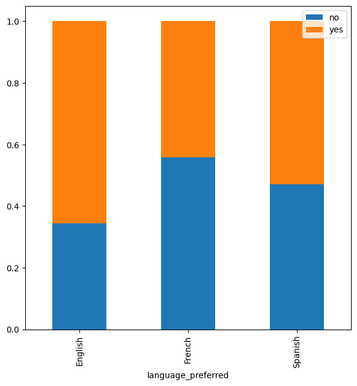

```python
# graphical comparison between conversion rate and preferred language
pd.crosstab(data['language_preferred'],data['converted'],normalize='index').plot(kind="bar", figsize=(7,7), stacked=True)
plt.legend()
plt.show()
```

**Observations:**

- **Language preferrence and conversion rate seems not to be related - testing will confirm it.**

### Null and alternate hypotheses

> $H_0:$ Conversion and language preference are independent.

> $H_a:$ Conversion and language preference are dependent.
- The variables are categorical
- The number of observations in each level is greater than 5.
- The population is randomly sampled

**Observation:**

**Chi-Square test for Independence is the appropriate test to use based on the above.**

**Significance level is given as 0.05 ($\alpha = 0.05$)**

### Collection and preparation of data

```python
# contingency table showing the distribution of the two categorical variables
pd.crosstab(data['language_preferred'],data['converted'])
```

| converted language_preferred | no | yes |
| --- | --- | --- |
| English | 11 | 21 |
| French | 19 | 15 |
| Spanish | 16 | 18 |

## P value calculation

```python
# required function importing
from scipy.stats import chi2_contingency
```

```python
# P value calculation
stat, p, dof, expected = chi2_contingency(pd.crosstab(data['language_preferred'],data['converted']))
print("P-value:", p)
```

```
P-value: 0.2129888748754345
```

### Comparing p-value with $\alpha$

```python
if p < 0.05:
    print("Reject null hypothesis")
else:
    print("Fail to reject null hypothesis")
```

```
Fail to reject null hypothesis
```

## **Conclusion:**

**Since the p-value(0.213) is greater than the significance level(0.05), we will fail to reject the null hypothesis. Hence, we do not have enough statistical significance to conclude that language preference and conversion are dependent at 5% significance level.**

## 4. Is the time spent on the new page same for the different language users?

```python
# import data for different language users on the new page
data_new = data[data['landing_page'] == 'new']
data_new.head()
```

|  | user_id | group | landing_page | time_spent_on_the_page | converted | language_preferred |
| --- | --- | --- | --- | --- | --- | --- |
| 1 | 546468 | treatment | new | 7.13 | yes | English |
| 2 | 546462 | treatment | new | 4.40 | no | Spanish |
| 4 | 546459 | treatment | new | 4.75 | yes | Spanish |
| 6 | 546448 | treatment | new | 5.25 | yes | French |
| 8 | 546461 | treatment | new | 10.71 | yes | French |

```python
data_new.shape
```

```
(50, 6)
```

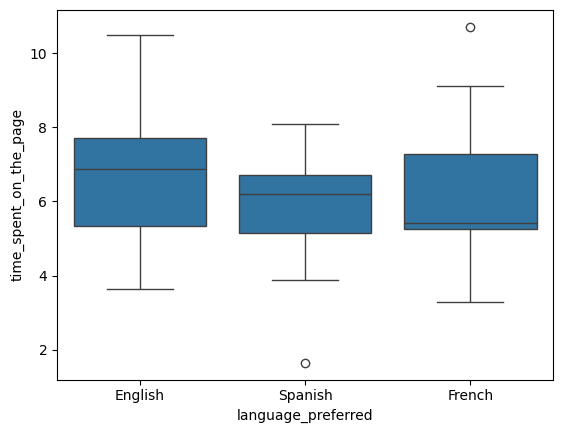

```python
# graphical representation of different language users on the new page with means
sns.boxplot(x='language_preferred', y='time_spent_on_the_page', data=data_new)
plt.show()
```

Let $\mu_1, \mu_2, \mu_3$ be the means of English, French and Spanish users time respectively on the new page.

Null hypothesis

> $H_0: \mu_1 = \mu_2 = \mu_3$

Alternative hypothesis

> $H_a: $ At least one language mean time is different from the rest.

**Appropriate test:** There are three population means to compare. Therefore, one way ANOVA test is the appropriate test to use. However, we need to verify the normality and equality of variance to conclude on the ANOVA test. This is done by

1. Shapiro-Wilk's test for normality
2. levene's test for equality of variance

**Shapiro-Wilk's test**

Null hypothesis

> $H_0:$ Time spent on the new page follows a normal distribution against

Alternative hypothesis

> $H_a:$ Time spent on the new page does not follow a normal distribution

```python
# required function import
from scipy import stats

# compute p value
stat, p_value = stats.shapiro(data_new['time_spent_on_the_page'])
print("P-value:", p_value)
```

```
P-value: 0.8040040364746845
```

**We fail to reject the null hypothesis which states that the time spent on the new page follows a normal distribution since the p value is large**

**Levene's test**

Null hypothesis

> $H_0$: All the population variances are equal

Alternative hypothesis

> $H_a$: At least one variance is different from the rest

```python
# required function import
from scipy.stats import levene
```

```python
 # compute p value
stat, p_value = levene(data_new[data_new['language_preferred'] == 'English']['time_spent_on_the_page'],
                        data_new[data_new['language_preferred'] == 'French']['time_spent_on_the_page'],data_new[data_new['language_preferred'] == 'Spanish']['time_spent_on_the_page'])
print("P-value:", p_value)
```

```
P-value: 0.46711357711340173
```

**We fail to reject the null hypothesis of equal population variances since the p value is larger than the significance level of 0.05**

**One way ANOVA test is therefore,the appropriate since it satisfies the list below**

- **Normal distributed population**
- **Equal population variances**
- **Independent random samples**

**Significance level is given as 0.05 ($\alpha = 0.05$)**

### Collection and preparation of data

```python
# data for english users on the new page
english_new = data_new[data_new['language_preferred'] == 'English']['time_spent_on_the_page']

# data for french users on the new page
french_new = data_new[data_new['language_preferred'] == 'French']['time_spent_on_the_page']

# data for spanish users on the new page
spanish_new = data_new[data_new['language_preferred'] == 'Spanish']['time_spent_on_the_page']
```

```python
print("English users on the new page:", english_new.shape[0])
print("French users on the new page:", french_new.shape[0])
print("Spanish users on the new page:", spanish_new.shape[0])
```

```
English users on the new page: 16
French users on the new page: 17
Spanish users on the new page: 17
```

```python
# Required function import
from scipy.stats import f_oneway
```

```python
# Compting p value
f_statistic, p_value = f_oneway(english_new, french_new, spanish_new)
print("P-value:", p_value)
```

```
P-value: 0.43204138694325955
```

### Comparing p-value with $\alpha$

```python
if p_value < 0.05:
    print("Reject null hypothesis")
else:
    print("Fail to reject null hypothesis")
```

```
Fail to reject null hypothesis
```

## **Conclusion:**

**Since the p-value(0.432) is greater than the significance level(0.05), we fail to reject the null hypothesis. Hence, we do not have enough statistical significance to conclude that at least one language mean time is different at 5% significance level.**

## Conclusion and Business Recommendations

**Recommendations;**

- **E-news Express should consider segmenting its news items.**
- **Subscription should be based on contents. (sports, movies,politics, tech, etc).**
- **E-news should offer special discounts on subscription based on the time spent on their landing page.**
- **Explore more language options rather than English, French and Spanish.**